# Bayesian analysis template

### Check priors

Next, you’ll want to check your priors by running this code chunk. It will produce a set of five sample plots drawn from the priors you set in the previous section, so you can check to see if the values generated are reasonable. (We’ll go into the details of this code later.)

**What to change**

Nothing! Just run this code to check your priors, adjusting prior values above as needed until you find reasonable prior values. Note that you may get a couple of very implausible or even impossible values because our assumption of normally distributed priors assigns a small probability to even very extreme values. If you are concerned by the outcome, you can try rerunning it a few more times to make sure that any implausible values you see don’t come up very often.

**Troubleshooting**

- In rare cases, you may get a warning that the Markov chains have failed to converge. Chains that fail to converge are a sign that your model is not a good fit to the data. If you get this warning, you should adjust your priors. Your prior distribution may be too narrow, and/or your prior mean is very far from the data.
- If you get any other errors, first double-check the values you have changed in the code chunks above (i.e. `mydata`, `mydata$x1`, `mydata$x2`, `mydata$y`, and prior values). Problems with these values can cause confusing errors downstream.

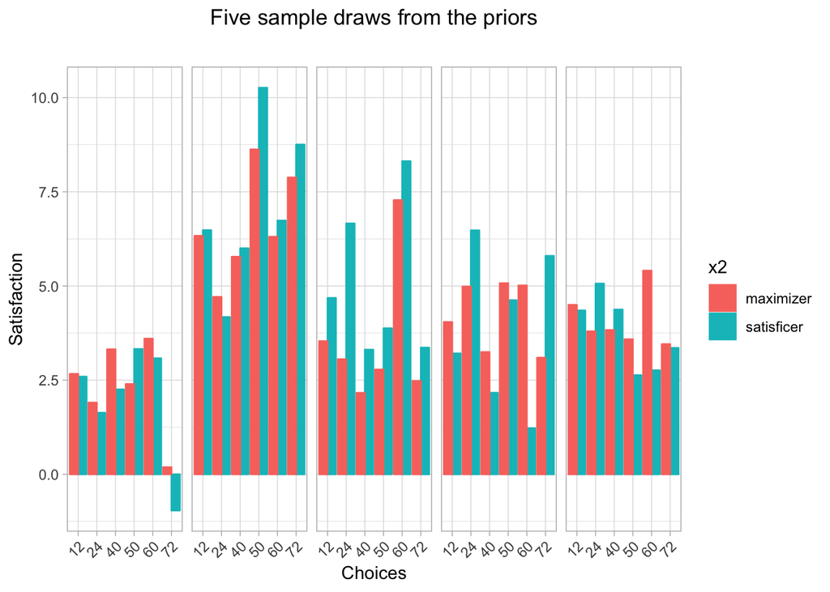

```r
#generate sample draws from the priors
m_prior = stan_glm(y ~ x1*x2, data = mydata,
  prior_intercept = normal(a_prior, a_sd, autoscale = FALSE),
  prior = normal(b1_prior, b1_sd, autoscale = FALSE),
  prior_PD = TRUE
)

#create the dataframe for fitted draws & plot the five sample draws
mydata %>%
  data_grid(x1,x2) %>%
  add_fitted_draws(m_prior, n = 5, seed = 12345) %>%
  ggplot(aes(x = x1, y = .value, col = x2, fill = x2, group = x2)) +
  geom_bar(stat='identity', position='dodge') +
  facet_grid(cols = vars(.draw)) +
  # coord_cartesian(ylim = c(min(mydata$y, na.rm=T), max(mydata$y, na.rm=T))) + # sets axis limits - CHANGE ME (optional)
  theme(strip.background = element_blank(),
        strip.text.y = element_blank(),
        axis.text.x = element_text(angle = 45, hjust = 1),
        plot.title = element_text(hjust = 0.5)) +
  labs(x=x_lab, y=y_lab) + # axes labels
  ggtitle("Five sample draws from the priors")
```

### Run the model

There’s nothing you have to change here. Just run the model.

**Troubleshooting:** If this code produces errors, check the troubleshooting section under the “Check priors” heading above for a few troubleshooting options.

```r
m = stan_glm(y ~ x1*x2, data = mydata,
  prior_intercept = normal(a_prior, a_sd, autoscale = FALSE),
  prior = normal(b1_prior, b1_sd, autoscale = FALSE)
)
```

## Model summary

Here is a summary of the model fit.

The summary reports diagnostic values that can help you evaluate whether your model is a good fit for the data. For this template, we can keep diagnostics simple: check that your `Rhat` values are very close to 1.0. Larger values mean that your model is not a good fit for the data. This is usually only a problem if the `Rhat` values are greater than 1.1, which is a warning sign that the Markov chains have failed to converge. In this happens, Stan will warn you about the failure, and you should adjust your priors.

```r
summary(m, digits=3)
```

```
##
## Model Info:
##
##  function:     stan_glm
##  family:       gaussian [identity]
##  formula:      y ~ x1 * x2
##  algorithm:    sampling
##  priors:       see help('prior_summary')
##  sample:       4000 (posterior sample size)
##  observations: 611
##  predictors:   12
##
## Estimates:
##                     mean     sd       2.5%     25%      50%      75%
## (Intercept)          6.116    0.120    5.878    6.037    6.116    6.196
## x124                -0.132    0.180   -0.489   -0.254   -0.134   -0.011
## x140                 0.172    0.171   -0.159    0.058    0.172    0.287
## x150                -0.115    0.163   -0.433   -0.225   -0.116   -0.011
## x160                -0.183    0.166   -0.511   -0.294   -0.178   -0.074
## x172                -0.020    0.178   -0.371   -0.140   -0.020    0.104
## x2satisficer         0.188    0.193   -0.196    0.062    0.193    0.314
## x124:x2satisficer   -0.099    0.302   -0.691   -0.296   -0.100    0.103
## x140:x2satisficer   -0.111    0.278   -0.660   -0.300   -0.109    0.075
## x150:x2satisficer    0.130    0.282   -0.421   -0.057    0.128    0.319
## x160:x2satisficer    0.083    0.284   -0.472   -0.110    0.080    0.279
## x172:x2satisficer   -0.021    0.277   -0.565   -0.213   -0.024    0.167
## sigma                1.025    0.030    0.969    1.005    1.024    1.045
## mean_PPD             6.133    0.060    6.016    6.093    6.133    6.173
## log-posterior     -895.634    2.558 -901.413 -897.175 -895.291 -893.776
##                     97.5%
## (Intercept)          6.352
## x124                 0.218
## x140                 0.512
## x150                 0.215
## x160                 0.145
## x172                 0.320
## x2satisficer         0.555
## x124:x2satisficer    0.503
## x140:x2satisficer    0.437
## x150:x2satisficer    0.685
```

[output cut: 10 more lines]

```
## x140              0.004 1.000 2193
## x150              0.003 1.000 2299
## x160              0.003 1.000 2258
## x172              0.004 1.000 2174
## x2satisficer      0.005 1.001 1537
## x124:x2satisficer 0.006 1.000 2250
## x140:x2satisficer 0.006 1.000 2129
## x150:x2satisficer 0.006 1.001 2187
## x160:x2satisficer 0.006 0.999 2251
## x172:x2satisficer 0.006 1.000 1953
## sigma             0.000 0.999 4000
## mean_PPD          0.001 1.000 4000
## log-posterior     0.065 1.002 1566
##
## For each parameter, mcse is Monte Carlo standard error, n_eff is a crude measure of effective sample size, and Rhat is the potential scale reduction factor on split chains (at convergence Rhat=1).
```

## Visualizing results

To plot the results, we will first construct a *fit grid*: a data frame of points at which we want to calculate a value from the model. The `data_grid` function allows us to do this easily, e.g. by asking for a point corresponding to every combination of values of the $x_1$ and $x_2$ variables in our original data:

```r
mydata %>%
  data_grid(x1, x2)
```

```
## # A tibble: 12 x 2
##    x1    x2
##    <fct> <fct>
##  1 12    maximizer
##  2 12    satisficer
##  3 24    maximizer
##  4 24    satisficer
##  5 40    maximizer
##  6 40    satisficer
##  7 50    maximizer
##  8 50    satisficer
##  9 60    maximizer
## 10 60    satisficer
## 11 72    maximizer
## 12 72    satisficer
```

Given this fit grid, we can then create any number of visualizations of the results. One way we might want to visualize the results is a static graph with error bars that represent 95% credible intervals. For each x position in the fit grid, we can get the posterior mean estimates and 95% credible intervals from the model:

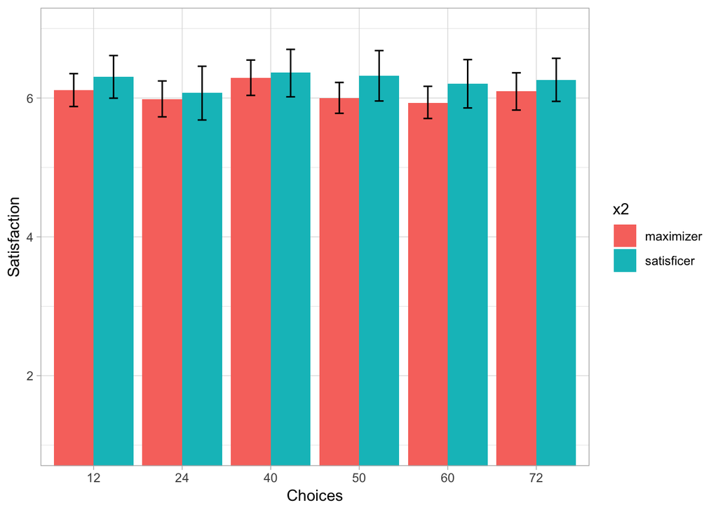

```r
fit = mydata %>%
      data_grid(x1, x2) %>%
      add_fitted_draws(m) %>%
      mean_qi(.width = .95)

ggplot(fit, aes(x = x1, y = .value, fill = x2, group = x2)) +
    geom_bar(stat='identity', position='dodge') +
    geom_errorbar(aes(ymin = .lower, ymax = .upper), position = position_dodge(width = .9), width = .2) +
    coord_cartesian(ylim = c(min(mydata$y, na.rm=T), max(mydata$y, na.rm=T))) + # sets axis limits
    labs(x=x_lab, y=y_lab)
```

Even better would be to animate this graph using HOPs (Hypothetical Outcomes Plot), a type of plot that visualizes uncertainty as sets of draws from a distribution, which has been demonstrated to improve multivariate probability estimates (Hullman et al. 2015) and increase sensitivity to the underlying trend in data (Kale et al. 2018) over static representations of uncertainty like error bars.

To set up the HOPs, we will first set the aesthetics for the ggplot that we will use.

### Plot aesthetics

You can set the aesthetics of your HOPs here.

**What to change**

In most cases, the default values here should be just fine. If you want to adjust the aesthetics of the animated plots later, you can do so here using the ggplot2 package; just be sure to keep the lines that are commented with “do not change.” Below are two optional code customizations that we think may be particularly useful for some datasets.

11. [Optional] coord_cartesian(ylim = …): You may want to manually set the y-axis limits. If so, uncomment this line in the code below and set your preferred limits accordingly.
12. [Optional] scale_x_discrete(limits = …): You may want to manually set the order of the x-axis levels; for example, if you have levels “before” and “after,” ggplot defaults often plot “after” on the left and “before” on the right. If so, uncomment this line in the code below and set your preferred level order. The names of the levels must match what is in your dataset.

```r
# the default code for the plots - if needed, the animated plot aesthetics can be customized here
graph_plot = function(data) {
  ggplot(data, aes(x = x1, y = .value, col = x2, fill = x2, group = x2)) + #do not change
    geom_bar(stat='identity', position='dodge') + #do not change
    transition_states(.draw, transition_length = 1, state_length = 1) + # gganimate code to animate the plots. Do not change
    theme(axis.text.x = element_text(angle = 45, hjust = 1)) + #rotates the x-axis text for readability
    coord_cartesian(ylim = c(min(mydata$y, na.rm=T), max(mydata$y, na.rm=T))) + # sets axis limits - CHANGE ME 11 (optional)
    # scale_x_discrete(limits=c("before","after")) + #manually set the order of the x-axis levels - CHANGE ME 12 (optional)
    labs(x=x_lab, y=y_lab) # axes labels
}

# Animation parameters
n_draws = 100 # the number of draws to visualize in the HOPs
frames_per_second = 2.5 # the speed of the HOPs
# 2.5 frames per second (400ms) is the recommended speed for the HOPs visualization.
# Faster speeds (100ms) have been demonstrated to not work as well.
# See Kale et al. VIS 2018 for more info.
```

Now that the plot aesthetics are set, we can return to our fit grid and repeatedly draw samples from the posterior mean evaluated at each x position in the grid using the `add_fitted_draws` function. Each frame of the animation shows a different draw from the posterior:

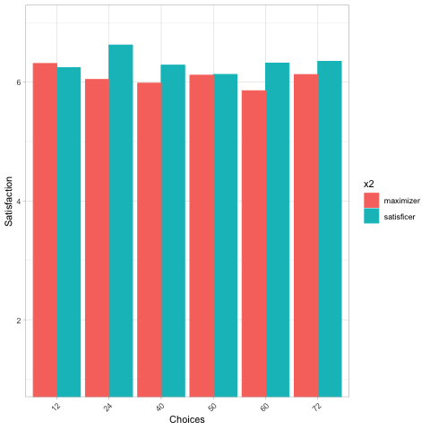

```r
p <- mydata %>% #pipe mydata to datagrid()
  data_grid(x1, x2) %>% #create a fit grid with each level in x, and pipe it to add_fitted_draws()
  add_fitted_draws(m, n = n_draws, seed = 12345) #add n fitted draws from the model to the fit grid
  # the seed argument is for reproducibility: it ensures the pseudo-random
  # number generator used to pick draws has the same seed on every run,
  # so that someone else can re-run this code and verify their output matches

#animate the data from p, using the graph aesthetics set in the graph aesthetics code chunk
animate(graph_plot(p), nframes = n_draws * 2, fps = frames_per_second)
```

## Sampling from the prior

We already looked at some sample plots of the priors when we were setting priors; now we want to look at these priors again, but in a HOPs format so we can compare to the posterior plots. To get the prior plots, we can simply ask `stan_glm` to sample from the prior.

**What to change**

If you are knitting this document, or if you already ran the code in the “Check priors” section that calculates m_prior, you can comment out this line:

```r
#m_prior = update(m, prior_PD = TRUE)
```

Then our code to generate plots is identical, except we replace `m` with `m_prior`:

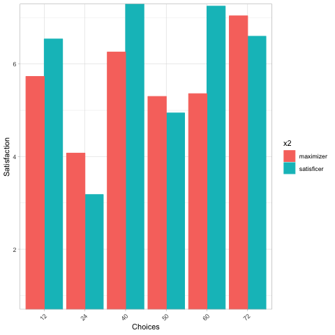

```r
p_prior = mydata %>%
  data_grid(x1, x2) %>%
  add_fitted_draws(m_prior, n = n_draws, seed = 12345)

animate(graph_plot(p_prior), nframes = n_draws * 2, fps = frames_per_second)
```